# Web Scraping using R

03/01/2018

## What is web scraping?

Web scraping is a technique for converting the data present in unstructured format (HTML tags) over the web to structured format which can easily be accessed and used. The job is carried out by a piece of code which is called a “scraper”.

First, it sends a “GET” query to a specific website. Then, it parses an HTML document based on the received result. After it’s done, the scraper searches for the data you need within the document, and, finally, converts it into whatever specified format.

## Web crawling vs web scraping: what are the differences?

### Web crawling

Web crawling, means the usage of programs or automated scripts which browse the World Wide Web in a methodical, automated manner. Google, Bing and Yahoo, essentially, are the major web crawlers. Crawlers can be used to gather specific types of information from Web pages, such as harvesting e-mail addresses (usually for spam). [Example 1](https://imgur.com/a/aX4yX) [Example 2](http://merlot.stat.uconn.edu/~jyan/)

## Web crawling vs web scraping: what are the differences?

### Web scraping

Web scraping is also same as finding required data from web pages. But in scraping, we know the exact page from which we need to scrap the data. We also know the html element structure of the webpages as they are fixed. Compared to web crawling, it is more targeted.

## Why do we need web scraping?

Web scraping has immense possibilities in application. Examples are:

- Scraping movie rating data from IMDB to create movie recommendation engines
- Scraping text data from Wikipedia and other sources to make NLP-based systems
- Scraping labeled image data from websites like Google, Pinterest, Flickr, etc. to train image classification models
- Scraping data from social media sites like Facebook and Twitter for performing sentiment analysis, oponion mining, etc.
- Scraping user reviews and feedbacks from e-commerce sites like Amazon

## Ways to scrap data

- **Human copy-paste**: slow and inefficient
- **Text pattern matching**: use regular expression matching
- **API interface**: many websites Facebook and Twitter provides public/private APIs which can be called using standard code to retrive data in prescribed format
- **DOM parsing**: by using the web browsers, programs can retrive the dynamic content generated by client-based-scripts. It’s also possible to parse web pages into a DOM tree, based on which programs can retrive parts of these pages

## Packages for web scraping in R

- `httr`: provides a user-friendly interface for executing HTTP methods
- `RCurl`: provides a closer interface between `R` and the `libcurl` `C` library, but less user-friendly
- `curl`: another `libcurl` client; provides the `curl()` function as an SSL-compatible replacement for base R’s `url()` and support for http 2.0, ssl, gzip, deflate and more
- `request`: provides a high-level package that is useful for developing other API client packages

## Packages for web scraping in R

- `RSelenium`: automate interactions and extract page contents of dynamically generated webpages (those requiring user interaction to display results)
- `Rcrawler`: performs parallel web crawling and web scraping; designed to crawl, parse and store web pages to produce data that can be directly used for analysis application.
- `rvest`: a higher-level alternative package useful for web scraping; works with `magrittr` to make it easy to express common web scraping tasks
- `twitteR`: an `R` based Twitter client that procides an interface to the Twitter web API

For more information: [CRAN Task View - Web Technologies and Services](https://cran.r-project.org/web/views/WebTechnologies.html)

## Example 1: IMDB Movies

Let’s scrap the IMDB website for the 100 most popular feature films released in 2017. The website is [here](http://www.imdb.com/search/title?count=100&release_date=2017,2017&title_type=feature).

```r
library(rvest)
# specify the url for desired website to be scrapped
url <- "http://www.imdb.com/search/title?count=100&release_date=2017,2017&title_type=feature"

# read in the HTML code from the website
webpage <- read_html(url)
```

## Example 1: IMDB Movies

### What does the page contain?

- Rank: the rank of the film by popularity
- Title: the title of the feature film
- Description: the description of the film
- Runtime: the duration of the film
- Genre: the genre of the feature film
- Rating: the IMDB rating of the feature film
- Metascore: the metascore on IMDB website for the feature film

## Example 1: IMDB Movies

- Votes: votes cast in favor of the feature film
- Gross_Earning_in_Mil: gross earnings of the feature film in millions
- Director: The main director of the feature film. In cases where there are multiple directors, we take the first one.
- Actor: The main actor/actress of the feature film. In cases where there are multiple actors/actresses, we take the first one.

## Example 1: IMDB Movies

### Start with the rankings

```r
# rankings
rank_data_html <- html_nodes(webpage, ".text-primary")
rank_data <- as.numeric(html_text(rank_data_html))
# names
title_data_html <- html_nodes(webpage, ".lister-item-header a")
title_data <- html_text(title_data_html)

head(data.frame(title_data, rank_data))
```

```
##                                  title_data rank_data
## 1                        The Shape of Water         1
## 2 Three Billboards Outside Ebbing, Missouri         2
## 3                            Thor: Ragnarok         3
## 4                      The Greatest Showman         4
## 5                            Justice League         5
## 6                      Call Me by Your Name         6
```

## Example 1: IMDB Movies

Similarly, identify the Description, Runtime, Genre, Rating, Metascore, Votes, Gross Earning, Director and Actor

```r
description_data_html <- html_nodes(webpage,
                        ".ratings-bar+ .text-muted")
description_data <- html_text(description_data_html)

head(description_data)
```

```
## [1] "\nAt a top secret research facility in the 1960s, a lonely janitor forms a unique relationship with an amphibious creature that is being held in captivity."
## [2] "\nA mother personally challenges the local authorities to solve her daughter's murder when they fail to catch the culprit."
## [3] "\nThor is imprisoned on the other side of the universe and finds himself in a race against time to get back to Asgard to stop Ragnarok, the destruction of his homeworld and the end of ...                See full summary »\n"
## [4] "\nCelebrates the birth of show business, and tells of a visionary who rose from nothing to create a spectacle that became a worldwide sensation."
## [5] "\nFueled by his restored faith in humanity and inspired by Superman's selfless act, Bruce Wayne enlists the help of his newfound ally, Diana Prince, to face an even greater enemy."
## [6] "\nIn 1980s Italy, a romance blossoms between a seventeen year-old student and the older man hired as his father's research assistant."
```

## Example 1: IMDB Movies

```r
runtime_data_html <- html_nodes(webpage, ".text-muted .runtime")
runtime_data <- html_text(runtime_data_html)
head(runtime_data)
```

```
## [1] "123 min" "115 min" "130 min" "105 min" "120 min" "132 min"
```

```r
runtime_data <- as.numeric(gsub(" min","", runtime_data))
```

## Example 1: IMDB Movies

Metascore: what goes wrong?

```r
metascore_data_html <- html_nodes(webpage,'.metascore')
metascore_data <- html_text(metascore_data_html)
metascore_data<-gsub(" ","",metascore_data)
length(metascore_data)
```

```
## [1] 94
```

## Example 1: IMDB Movies

Six of the top 100 movies didn’t have a metascore!

```r
for (i in c(11, 29, 33, 39, 59, 85)) {
    a <- metascore_data[1:(i - 1)]
    b <- metascore_data[i:length(metascore_data)]
    metascore_data <- append(a, list("NA"))
    metascore_data <- append(metascore_data, b)
}
metascore_data <- as.numeric(metascore_data)
```

## Example 1: IMDB Movies

Combine everything into a single dataframe.

```
## 'data.frame':    100 obs. of  11 variables:
##  $ Rank                : num  1 2 3 4 5 6 7 8 9 10 ...
##  $ Title               : Factor w/ 100 levels "A Bad Moms Christmas",..: 84 89 87 74 38 13 96 42 10 18 ...
##  $ Description         : Factor w/ 100 levels "\n1920, rural Ireland. Anglo Irish twins Rachel and Edward share a strange existence in their crumbling family "| __truncated__,..: 37 10 88 45 54 58 41 59 18 49 ...
##  $ Runtime             : num  123 115 130 105 120 132 113 94 164 125 ...
##  $ Genre               : Factor w/ 9 levels "Action","Adventure",..: 2 6 1 4 1 7 7 5 7 4 ...
##  $ Rating              : num  7.7 8.3 8 8 6.8 8.1 8 7.7 8.2 7.4 ...
##  $ Metascore           : num  87 88 74 48 45 93 66 94 81 75 ...
##  $ Votes               : num  99060 141128 252875 71813 203451 ...
##  $ Gross_Earning_in_Mil: num  55.5 50.3 314.8 161 228.9 ...
##  $ Director            : Factor w/ 99 levels "Aaron Sorkin",..: 39 61 89 67 99 57 86 38 30 48 ...
##  $ Actor               : Factor w/ 92 levels "Andy Serkis",..: 77 34 21 41 8 6 43 78 40 36 ...
```

## Example 1: IMDB Movies

```r
p1 <- ggplot(movies_df, aes(x = Runtime, y = Rating)) +
    geom_point(aes(size = Votes, col = Genre))
ggplotly(p1)
```

[interactive chart not shown]

## Example 1: IMDB Movies

```r
ggplotly(ggplot(movies_df, aes(x = Runtime, fill = Genre)) +
             geom_bar(stat = "count"))
```

[interactive chart not shown]

## Example 2: Twitter Data

Initial setup: generate `consumer_key`, `consumer_secret`, `access_token`, `access_secret` from [Twitter Application Management](https://apps.twitter.com), and use them to authorize your `R` session.

```r
library(twitteR)
setup_twitter_oauth(consumer_key, consumer_secret,
                    access_token, access_secret)
```

```
## [1] "Using direct authentication"
```

## Example 2: Twitter Data

```r
searchResults <- searchTwitteR("#coco", n = 100)
head(searchResults)
```

```
## [[1]]
## [1] "ryandbkimmel: Watched #Coco last night with the kids. It was great! https://t.co/dFyrZbqJFP"
##
## [[2]]
## [1] "mileniotv: RT @Mileniohey: ❤ ¿Ya conoces qué galardones se llevó #Coco durante el circuito de premios? Nosotros te lo decimos \xed\xa0\xbd\xed\xb1\x89 https://t.co/R4uerdinS…"
##
## [[3]]
## [1] "Milenio: RT @Mileniohey: ❤ ¿Ya conoces qué galardones se llevó #Coco durante el circuito de premios? Nosotros te lo decimos \xed\xa0\xbd\xed\xb1\x89 https://t.co/R4uerdinS…"
##
## [[4]]
## [1] "Zalo_con_Z: RT @NovenusT: Las gemelas de \"El Resplandor\" aparecen en \"#Coco\" y ni te enteraste - https://t.co/wgmKUE3YHn\n-----\n#CineTv #Disney #ElRespl…"
##
## [[5]]
## [1] "SpaceDuck90: I got the @Target exclusive version of #Coco and I can't wait to watch it when I get home. \xed\xa0\xbd\xed\xb2\x95"
##
## [[6]]
## [1] "JenGustaf: #Coco is one of my top 3 favorite @DisneyPixar films. The teams just knocked it out of the park with this one. https://t.co/9DDJkDY5E6"
```

## Example 2: Twitter Data

```r
searchResults <- searchTwitteR("#coco", n = 3000, lang = "en")
head(searchResults)
```

```
## [[1]]
## [1] "ryandbkimmel: Watched #Coco last night with the kids. It was great! https://t.co/dFyrZbqJFP"
##
## [[2]]
## [1] "SpaceDuck90: I got the @Target exclusive version of #Coco and I can't wait to watch it when I get home. \xed\xa0\xbd\xed\xb2\x95"
##
## [[3]]
## [1] "JenGustaf: #Coco is one of my top 3 favorite @DisneyPixar films. The teams just knocked it out of the park with this one. https://t.co/9DDJkDY5E6"
##
## [[4]]
## [1] "upcomingpixar: TBH, every day should be #Coco Day in Los Angeles: https://t.co/4n6sr80Hty https://t.co/efBZhYeQSf"
##
## [[5]]
## [1] "BryaanMenjivar: RT @disneyfilmfacts: COCO director Lee Unkrich reveals THE SHINING easter egg that nobody noticed! #Coco https://t.co/bPfewM4Ljz"
##
## [[6]]
## [1] "Officialshelore: Call it  #coco or #charlie  #Lucy or #simba @wizkidayo"
```

## Example 2: Twitter Data

[interactive chart not shown]

## Example 2: Twitter Data

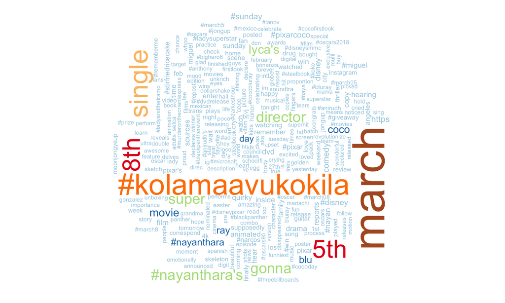

## One more thing: word cloud about Donald Trump

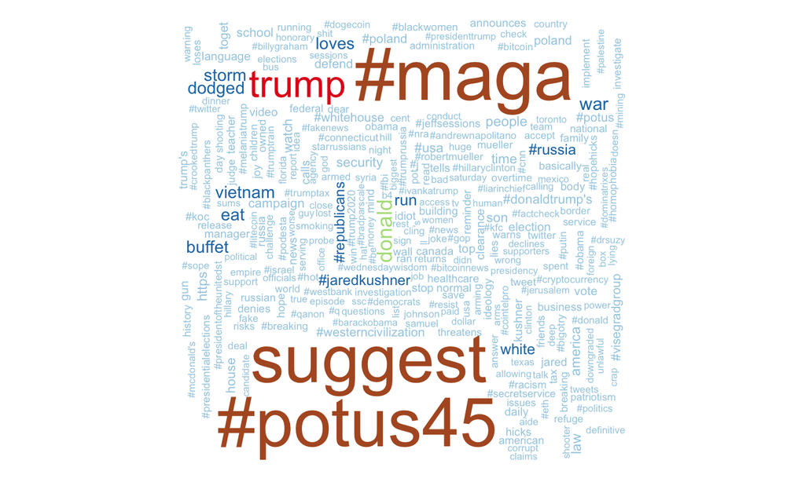

## For large, formulated websites: customized packages

`Rfacebook`, `Rlinkedin`, `RGoogleData`, `googlesheets`

These packages are very similar to `twitteR`, as they all require specific API’s from the websites. You’ll need to create a web app.

[facebook](https://developers.facebook.com/apps)

[linkedin](https://developer.linkedin.com/)

[googlesheets, RGoogleData](https://console.developers.google.com/apis/dashboard?project=groovy-form-88400&duration=PT1H)

## More reading:

[Rcrawler: An R package for parallel web crawling and scraping](https://www.sciencedirect.com/science/article/pii/S2352711017300110)

[UC Business Analytics R Programming Guide: Scraping Data](http://uc-r.github.io/scraping)

[Examples of Web Scraping With R](http://www.programmingr.com/examples/examples-web-scraping-r/)

[Conducting Web-based Research in R](http://www.columbia.edu/~cjd11/charles_dimaggio/DIRE/styled-4/styled-6/code-13/)